# STATS506_hw2

Author

Xingjian Liu

```r
knitr::opts_chunk$set(error=TRUE)
```

GitHub: https://github.com/CherryLIUxj/STATS506_proj/tree/master

# Problem 1 **- Dice Game**

## a.

### Version 1: Implement this game using a loop over the die rolls.

```r
dice_output <- function(input){
  if (input %in% c(2,4,6)){
    return (input-2)
  }
  else {return (-2)}
}
```

```r
play_dice_1 <- function(rounds){
  output <- 0
  for (i in 1:rounds){
    input <- sample(1:6,1)
    # cat(sprintf('Round %d: input=%d\n', i,input))
    output <- output + dice_output(input)
  }
  return (output)
}
```

### Version 2: Implement this game using built-in R vectorized functions

```r
play_dice_2 <- function(rounds){
  input_vec <- sample(1:6,rounds,replace=TRUE)
  # print(input_vec)
  gain <- ifelse(input_vec %% 2 == 0, input_vec-2, -2)
  output <- sum(gain)
  return (output)
}
```

### Version 3: Implement this by collapsing the die rolls into a single `table()`

```r
play_dice_3 <- function(rounds){
  input_vec <- sample(1:6,rounds,replace=TRUE)
  input_table <- table(input_vec)
  output <- 0
  for (i in 1:length(input_table)){
    output <- output + dice_output(as.integer(names(input_table[i])))*as.integer(input_table[i])
    # Note: do not break the line before '+' !!
  }
  return (output)
}
```

### Version 4: Implement this game by using one of the “`apply`” functions.

```r
play_dice_4 <- function(rounds){
  input_vec <- sample(1:6,rounds,replace=TRUE)
  output_vec <- sapply(input_vec,dice_output)
  output <- sum(output_vec)
  return (output)
}
```

## b. Demonstrate that all versions work. Do so by running each a few times, once with an input of 3, and once with an input of 3000.

### Test Version 1:

```r
cat('Test 1:',play_dice_1(3),play_dice_1(3000),'\n')
```

```
Test 1: -2 -132
```

```r
cat('Test 2:',play_dice_1(3),play_dice_1(3000),'\n')
```

```
Test 2: 2 -204
```

```r
cat('Test 3:',play_dice_1(3),play_dice_1(3000),'\n')
```

```
Test 3: 0 -194
```

### Test Version 2:

```r
cat('Test 1:',play_dice_2(3),play_dice_2(3000),'\n')
```

```
Test 1: 6 -96
```

```r
cat('Test 2:',play_dice_2(3),play_dice_2(3000),'\n')
```

```
Test 2: 4 30
```

```r
cat('Test 3:',play_dice_2(3),play_dice_2(3000),'\n')
```

```
Test 3: -2 -2
```

### Test Version 3:

```r
cat('Test 1:',play_dice_3(3),play_dice_3(3000),'\n')
```

```
Test 1: 10 -172
```

```r
cat('Test 2:',play_dice_3(3),play_dice_3(3000),'\n')
```

```
Test 2: 2 -192
```

```r
cat('Test 3:',play_dice_3(3),play_dice_3(3000),'\n')
```

```
Test 3: -2 20
```

### Test Version 4:

```r
cat('Test 1:',play_dice_4(3),play_dice_4(3000),'\n')
```

```
Test 1: -2 -208
```

```r
cat('Test 2:',play_dice_4(3),play_dice_4(3000),'\n')
```

```
Test 2: -2 204
```

```r
cat('Test 3:',play_dice_4(3),play_dice_4(3000),'\n')
```

```
Test 3: -2 58
```

## c. Demonstrate that the four versions give the same result. Test with inputs 3 and 3000. (You may need to add a way to control the randomization.)

```r
set.seed(10)
play_dice_1(3)
```

```
[1] -4
```

```r
set.seed(10)
play_dice_2(3)
```

```
[1] -4
```

```r
set.seed(10)
play_dice_3(3)
```

```
[1] -4
```

```r
set.seed(10)
play_dice_4(3)
```

```
[1] -4
```

```r
set.seed(30)
play_dice_1(3000)
```

```
[1] -32
```

```r
set.seed(30)
play_dice_2(3000)
```

```
[1] -32
```

```r
set.seed(30)
play_dice_3(3000)
```

```
[1] -32
```

```r
set.seed(30)
play_dice_4(3000)
```

```
[1] -32
```

## d. Use the *microbenchmark* package to clearly demonstrate the speed of the implementations. Compare performance with a low input (100) and a large input (10000). Discuss the results

```r
install.packages('microbenchmark')
```

```
Error in contrib.url(repos, "source"): trying to use CRAN without setting a mirror
```

```r
library(microbenchmark)
```

```r
microbenchmark(a=play_dice_1(100),
               b=play_dice_2(100),
               c=play_dice_3(100),
               d=play_dice_4(100))
```

```
Unit: microseconds
 expr     min       lq      mean  median       uq      max neval
    a 699.736 733.5525 857.97855 816.995 875.0020 3110.111   100
    b  25.168  30.5770  35.30896  35.049  40.1130   50.618   100
    c 170.882 192.8835 215.09524 206.150 222.9380  522.027   100
    d 177.392 188.2840 204.07096 195.078 203.2935  603.246   100
```

```r
microbenchmark(a=play_dice_1(10000),
               b=play_dice_2(10000),
               c=play_dice_3(10000),
               d=play_dice_4(10000))
```

```
Unit: microseconds
 expr      min        lq      mean    median        uq        max neval
    a 75761.53 81955.729 88895.105 85954.798 91186.514 144751.301   100
    b   779.34   971.840  1095.479  1112.746  1183.968   1680.294   100
    c  1188.68  1420.178  1565.710  1546.008  1666.902   2172.389   100
    d 16091.36 18102.807 20336.118 19868.174 21773.567  32097.102   100
```

* where decline percentage of speed is calculated as:

$(runtime_{10000} - runtime_{100})/runtime_{10000}$

## e. Do you think this is a fair game? Defend your decision with evidence based upon a Monte Carlo simulation.

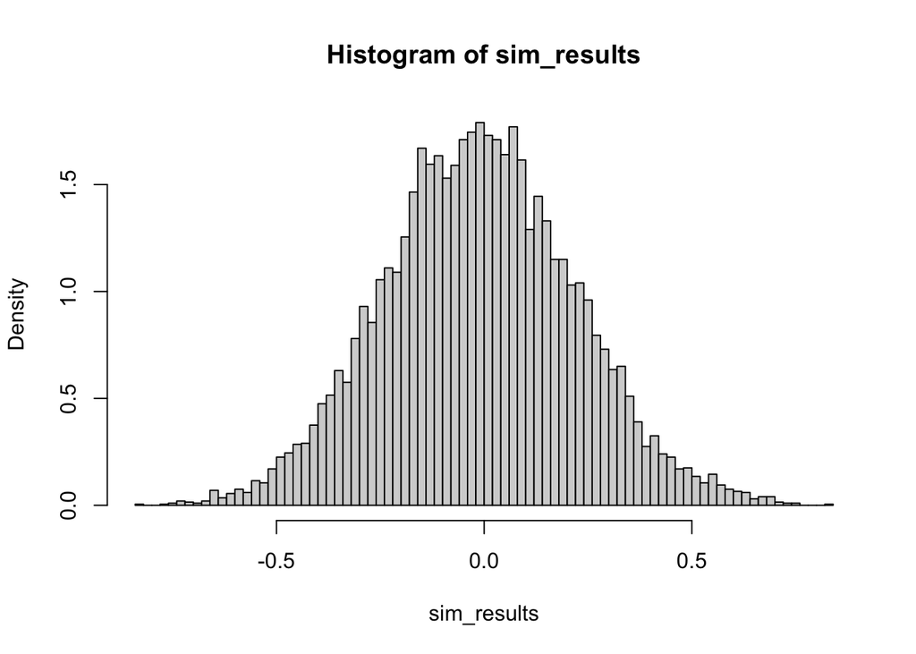

```r
# Generate 1000 simulations with different random seeds, in each of which the player rolls the dice 100 times and we calculate the average of his winning or loss.
# See if most of the  results are close to 0

sim_results <- numeric(1000)

for (i in 1:10000){
  set.seed(i)
  sim_results[i] <- play_dice_2(100)/100
}
hist(sim_results,breaks=100,probability = TRUE)
```

```r
mean(sim_results)
```

```
[1] -0.001428
```

```r
median(sim_results)
```

```
[1] 0
```

```r
quantile(sim_results)
```

```
   0%   25%   50%   75%  100%
-0.84 -0.16  0.00  0.16  0.84
```

From above, we can see that most of the average winnings (or losses) are close to 0.

Thus, we can ensure the fairness of the game.

# Problem 2 - Linear Regression

```r
cars <- read.csv('cars.csv')
```

```r
names(cars)
```

```
 [1] "Dimensions.Height"
 [2] "Dimensions.Length"
 [3] "Dimensions.Width"
 [4] "Engine.Information.Driveline"
 [5] "Engine.Information.Engine.Type"
 [6] "Engine.Information.Hybrid"
 [7] "Engine.Information.Number.of.Forward.Gears"
 [8] "Engine.Information.Transmission"
 [9] "Fuel.Information.City.mpg"
[10] "Fuel.Information.Fuel.Type"
[11] "Fuel.Information.Highway.mpg"
[12] "Identification.Classification"
[13] "Identification.ID"
[14] "Identification.Make"
[15] "Identification.Model.Year"
[16] "Identification.Year"
[17] "Engine.Information.Engine.Statistics.Horsepower"
[18] "Engine.Information.Engine.Statistics.Torque"
```

## a. The names of the variables in this data are way too long. Rename the columns of the data to more reasonable lengths

```r
names(cars) <- c('H','L','W','eng_drive','eng_type','eng_hybrid','eng_gears','eng_trans','fuel_ctmpg','fuel_type','fuel_hwmpg','class','id','make','mod_year','year','eng_horsepower','eng_torque')
```

## b. Restrict the data to cars whose Fuel Type is “Gasoline”

```r
table(cars$fuel_type)
```

```
Compressed natural gas            Diesel fuel                    E85
                     2                     27                    456
              Gasoline
                  4591
```

```r
gas_cars <- cars[which(cars$fuel_type=='Gasoline'),]
dim(cars)
```

```
[1] 5076   18
```

```r
dim(gas_cars)
```

```
[1] 4591   18
```

## c. Fit a linear regression model predicting MPG on the highway. The predictor of interest is horsepower.

```r
gas_cars$year <- as.factor(gas_cars$year)
```

```r
table(gas_cars$year)
```

```
2009 2010 2011 2012
  48 1633 1794 1116
```

```r
mod <- lm(fuel_hwmpg~eng_horsepower+eng_torque+H+L+W+year, data=gas_cars)
summary(mod)
```

```
Call:
lm(formula = fuel_hwmpg ~ eng_horsepower + eng_torque + H + L +
    W + year, data = gas_cars)

Residuals:
    Min      1Q  Median      3Q     Max
-10.824  -2.550  -0.452   2.372 202.639

Coefficients:
                 Estimate Std. Error t value Pr(>|t|)
(Intercept)    32.2926630  0.7225982  44.690  < 2e-16 ***
eng_horsepower  0.0163556  0.0022772   7.182 7.96e-13 ***
eng_torque     -0.0507425  0.0022030 -23.034  < 2e-16 ***
H               0.0099079  0.0011267   8.794  < 2e-16 ***
L               0.0017290  0.0008836   1.957   0.0504 .
W              -0.0003343  0.0009045  -0.370   0.7117
year2010       -0.4539681  0.6768246  -0.671   0.5024
year2011        0.1711016  0.6757043   0.253   0.8001
year2012        1.3029279  0.6810076   1.913   0.0558 .
---
Signif. codes:  0 '***' 0.001 '**' 0.01 '*' 0.05 '.' 0.1 ' ' 1

Residual standard error: 4.602 on 4582 degrees of freedom
Multiple R-squared:  0.4192,    Adjusted R-squared:  0.4182
F-statistic: 413.3 on 8 and 4582 DF,  p-value: < 2.2e-16
```

Controlling for the other predictors, we can see that

$$\Delta fuel\_hwmpg = \Delta 0.0163556 * eng\_horsepower$$

which means a unit increase in horse power (745.7 watts) will lead to an increase of 0.0163556 miles-per-gallon in Highway MPG.

## d. It seems reasonable that there may be an interaction between horsepower and torque. Refit the model (with `lm`) and generate an interaction plot, showing how the relationship between horsepower and MPG changes as torque changes. Choose reasonable values of horsepower, and show lines for three different reasonable values of torque.

### i) showing how the relationship between horsepower and MPG changes as torque changes

```r
mod2 <- lm(fuel_hwmpg~eng_horsepower*eng_torque+H+L+W+year, data=gas_cars)
summary(mod2)
```

```
Call:
lm(formula = fuel_hwmpg ~ eng_horsepower * eng_torque + H + L +
    W + year, data = gas_cars)

Residuals:
    Min      1Q  Median      3Q     Max
-11.109  -2.313  -0.258   2.062 203.540

Coefficients:
                            Estimate Std. Error t value Pr(>|t|)
(Intercept)                4.219e+01  7.930e-01  53.199  < 2e-16 ***
eng_horsepower            -1.666e-02  2.539e-03  -6.563 5.84e-11 ***
eng_torque                -8.606e-02  2.533e-03 -33.972  < 2e-16 ***
H                          6.560e-03  1.070e-03   6.133 9.32e-10 ***
L                          1.777e-03  8.318e-04   2.136   0.0327 *
W                         -1.169e-03  8.521e-04  -1.372   0.1700
year2010                  -5.628e-01  6.372e-01  -0.883   0.3771
year2011                   7.254e-02  6.361e-01   0.114   0.9092
year2012                   1.197e+00  6.411e-01   1.867   0.0619 .
eng_horsepower:eng_torque  1.124e-04  4.628e-06  24.276  < 2e-16 ***
---
Signif. codes:  0 '***' 0.001 '**' 0.01 '*' 0.05 '.' 0.1 ' ' 1

Residual standard error: 4.333 on 4581 degrees of freedom
Multiple R-squared:  0.4854,    Adjusted R-squared:  0.4844
F-statistic: 480.1 on 9 and 4581 DF,  p-value: < 2.2e-16
```

From above we can see that

$$fuel\_hwmpg = -1.666\times10^{-2}*eng\_horsepower - 8.606\times10^{-2}*eng\_torque + 1.124\times10^{-4}eng\_horsepower:eng\_torque$$

which can be written as

$$fuel\_hwmpg = (-1.666\times10^{-2}+1.124\times10^{-4}*eng\_torque)*eng\_horsepower - 8.606\times10^{-2}*eng\_torque$$

a unit increase in torque will lead to a $1.124\times10^{-4}$ increase in the coefficient of horsepower

which means if torque increase by 1 unit, then a unit increase(745.7 watts) in horsepower will lead to a $1.124\times10^{-4}$ miles-per-gallon more increase in the Highway MPG compared to the original torque.

### ii) Choose reasonable values of horsepower, and show lines for three different reasonable values of torque. (And choose a single reasonable value of year)

```r
install.packages("interactions")
```

```
Error in contrib.url(repos, "source"): trying to use CRAN without setting a mirror
```

```r
library(interactions)
```

- Look up the distribution of horsepower and torque data:

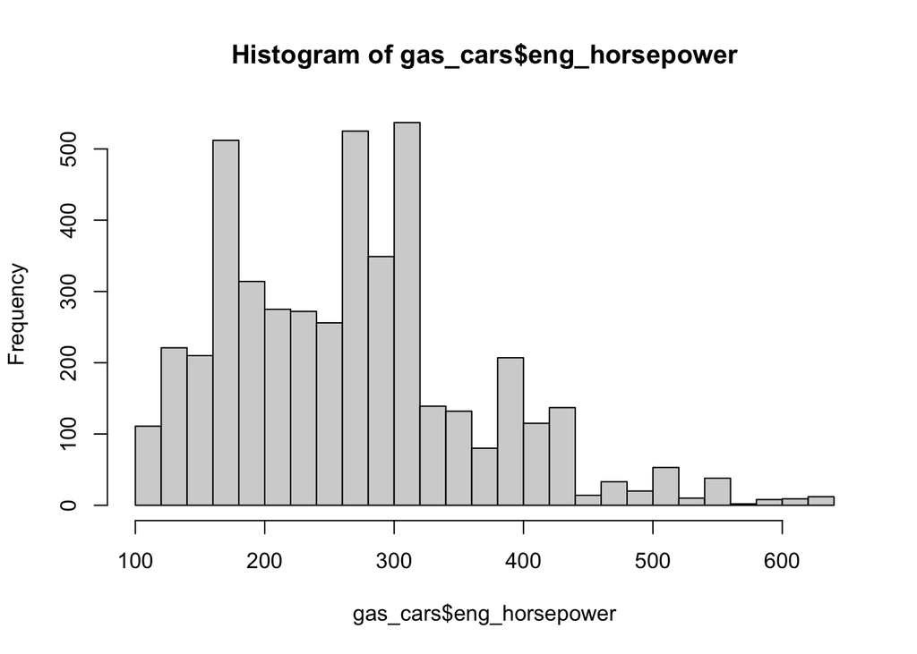

```r
hist(gas_cars$eng_horsepower, breaks=20)
```

```r
summary(gas_cars$eng_horsepower)
```

```
   Min. 1st Qu.  Median    Mean 3rd Qu.    Max.
  100.0   185.0   263.0   267.5   317.0   638.0
```

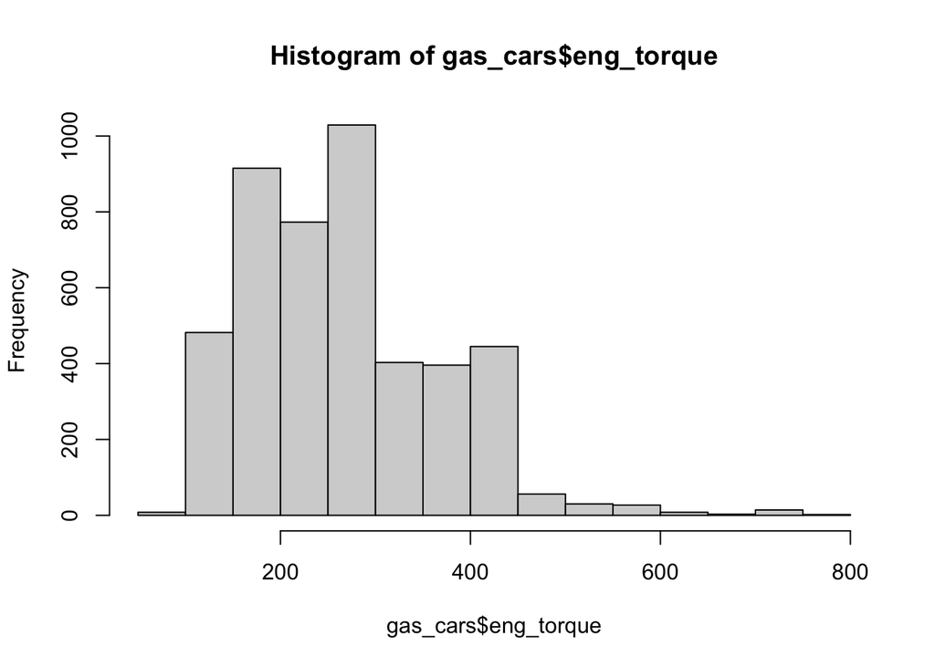

```r
hist(gas_cars$eng_torque, breaks=20)
```

```r
summary(gas_cars$eng_torque)
```

```
   Min. 1st Qu.  Median    Mean 3rd Qu.    Max.
   98.0   177.0   257.0   267.2   332.0   774.0
```

- Calculate the johnson_neyman interval for interaction terms in mod2, with predictor variable = horsepower and moderator variable = torque:

```
JOHNSON-NEYMAN INTERVAL

When eng_torque is OUTSIDE the interval [108.00, 186.70], the slope of
eng_horsepower is p < .05.

Note: The range of observed values of eng_torque is [98.00, 774.00]
```

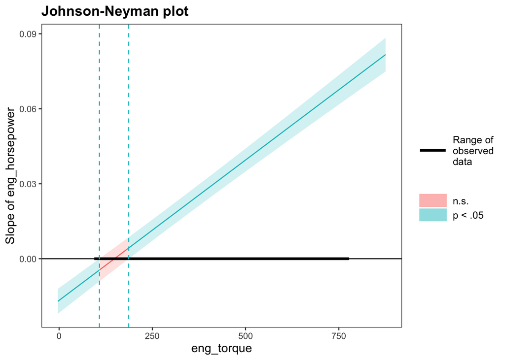

```r
johnson_neyman(mod2,pred=eng_horsepower, modx=eng_torque)
```

From above we can see that only if torque is OUTSIDE [108.00, 186.70] will horsepower be significant in the regression model.

So we can choose **257.0(Median), 267.2(Mean), 332.0 (3rd Qu.)** as three reasonable values for torque

- For controlling year, we can choose the mode **year=‘2011’** in this case

```r
table(gas_cars$year)
```

```
2009 2010 2011 2012
  48 1633 1794 1116
```

- Interaction Plot with specifically selected three torque and year:

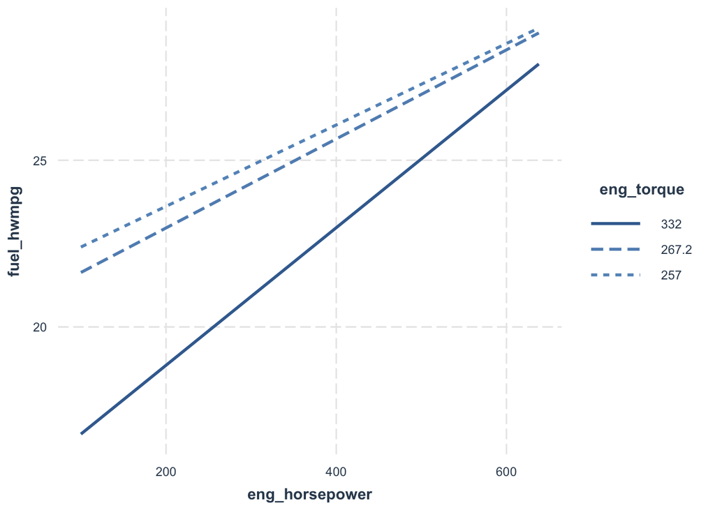

```r
interact_plot(mod2, pred=eng_horsepower, modx=eng_torque,modxvals=c(257,267.2,332),at=list(year='2011'))
```

## e. Calculate beta_hat from d. manually (without using `lm`) by first creating a proper design matrix, then using matrix algebra to estimate beta. Confirm that you get the same result as `lm` did prior.

```r
# design matrix
X <- model.matrix(fuel_hwmpg~eng_horsepower*eng_torque+H+L+W+year
, data=gas_cars)

# response variable
y <- gas_cars$fuel_hwmpg

# OLS Formula
beta <- solve(t(X) %*% X) %*% t(X) %*% y

beta
```

```
                                   [,1]
(Intercept)               42.1879478687
eng_horsepower            -0.0166633227
eng_torque                -0.0860592704
H                          0.0065603903
L                          0.0017767232
W                         -0.0011694485
year2010                  -0.5627857770
year2011                   0.0725356431
year2012                   1.1970329986
eng_horsepower:eng_torque  0.0001123567
```

```r
mod2$coefficients
```

```
              (Intercept)            eng_horsepower                eng_torque
            42.1879478687             -0.0166633227             -0.0860592704
                        H                         L                         W
             0.0065603903              0.0017767232             -0.0011694485
                 year2010                  year2011                  year2012
            -0.5627857770              0.0725356431              1.1970329986
eng_horsepower:eng_torque
             0.0001123567
```

the same.

# Problem 3 - Stata

Repeat problem 2 parts a. through d. in Stata.

```r
// confirm file path
pwd
// import dataset
. import delimited "/Users/liuxingjian/Documents/Stata/cars.csv", varnames(1)
//look up dataset
. describe
```

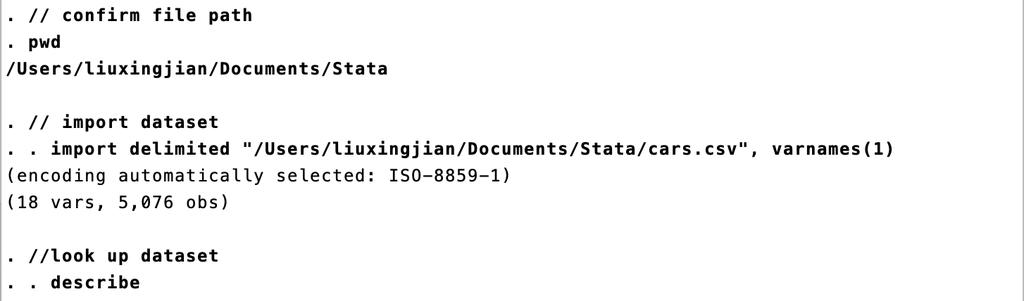

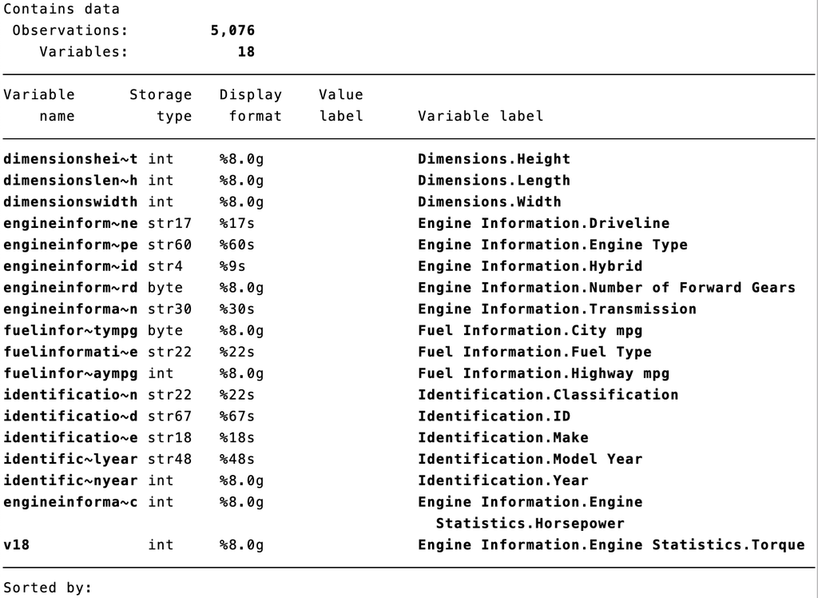

## a.

```r
// a. rename dataset
. rename dimensionsheight height
. rename dimensionslength length
. rename dimensionswidth width
. rename engineinformationdriveline driveline
. rename engineinformationenginetype engtype
. rename engineinformationhybrid hyb
. rename engineinformationnumberofforward numgears
. rename engineinformationtransmission trans
. rename fuelinformationcitympg ctmpg
. rename fuelinformationfueltype fueltype
. rename fuelinformationhighwaympg hwmpg
. rename identificationclassification classf
. rename identificationid id
. rename identificationmake make
. rename identificationmodelyear modyear
. rename identificationyear year
. rename engineinformationenginestatistic horsepower
. rename v18 torque

. describe
```

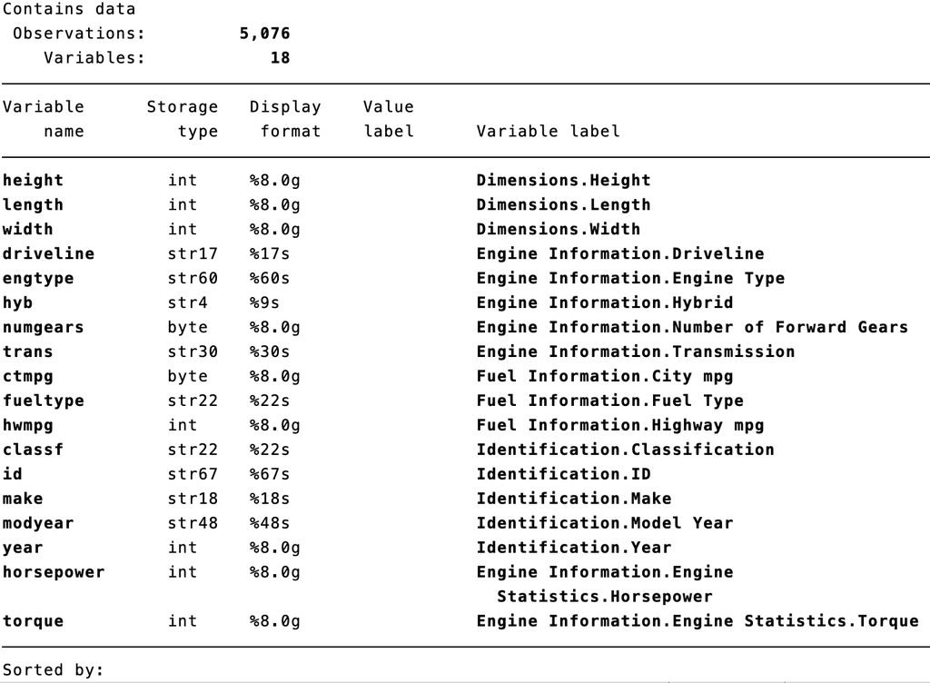

## b.

```r
// b. filter data to cars with Gasoline Fuel Type
. drop if fueltype != "Gasoline"
```

(485 observations deleted)

## c.

```r
// c. fit linear regression model
. regress hwmpg horsepower torque height length width i.year
```

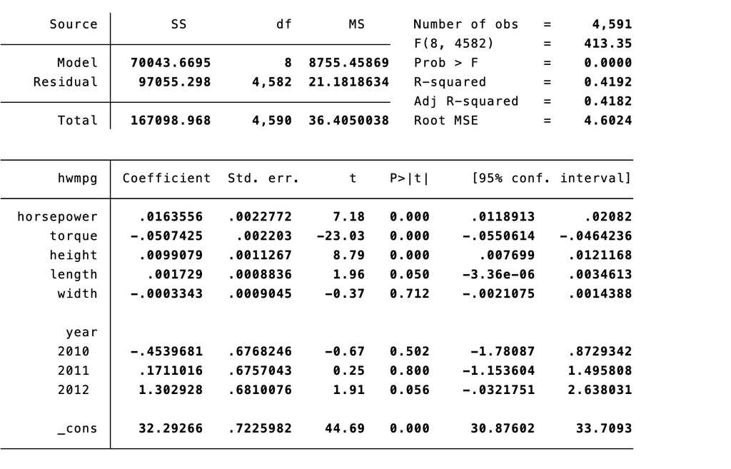

Controlling for the other predictors, we can see that

$$\Delta fuel\_hwmpg = \Delta 0.0163556 * eng\_horsepower$$

which means a unit increase in horse power (745.7 watts) will lead to an increase of 0.0163556 miles-per-gallon in Highway MPG.

## d.

### i) showing how the relationship between horsepower and MPG changes as torque changes

```r
// d.1 refit model by including interaction terms
. regress hwmpg c.horsepower##c.torque height length width i.year
```

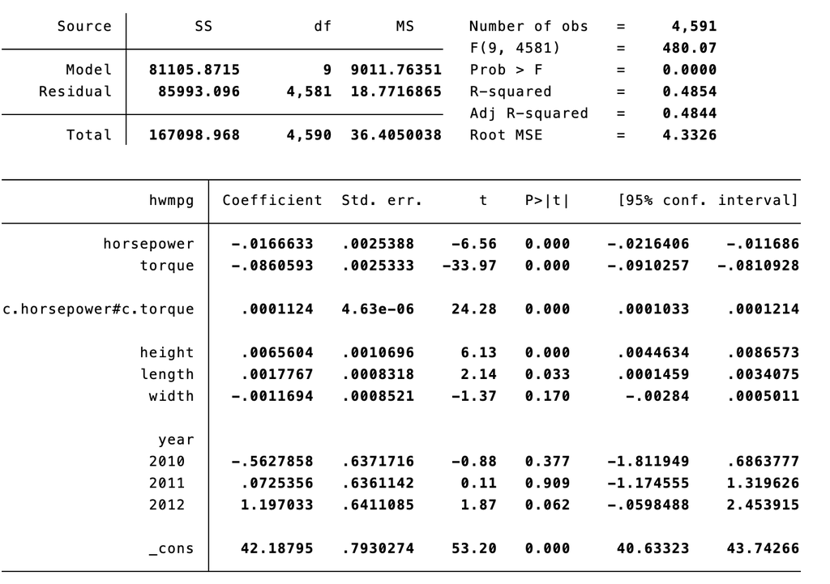

From above we can see that a unit increase in torque will lead to a $1.124\times10^{-4}$ increase in the coefficient of horsepower

which means if torque increase by 1 unit, then a unit increase(745.7 watts) in horsepower will lead to a $1.124\times10^{-4}$ miles-per-gallon more increase in the Highway MPG compared to the original torque.

### ii) Choose reasonable values of horsepower, and show lines for three different reasonable values of torque. (And choose a single reasonable value of year)

For the part below, we choose the same values for torque and year as problem 2. In order to plot the lines for highwaympg~horsepower, we select values of horsepower every 10 within [100,638], which is the observed range of horsepower.

```r
// d.2 show interact_plot
. margins, at(horsepower=(100(10)638) torque=(257,267.2,332) year=2011)
. marginsplot, noci recast(line) recastci(rarea) legend(order(1 "torque=257" 2 "torque=267.2" 3 "torque=332"))
```

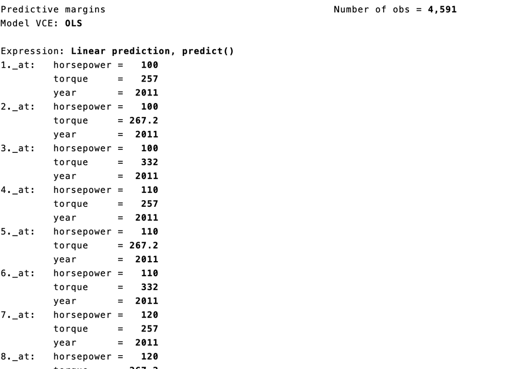

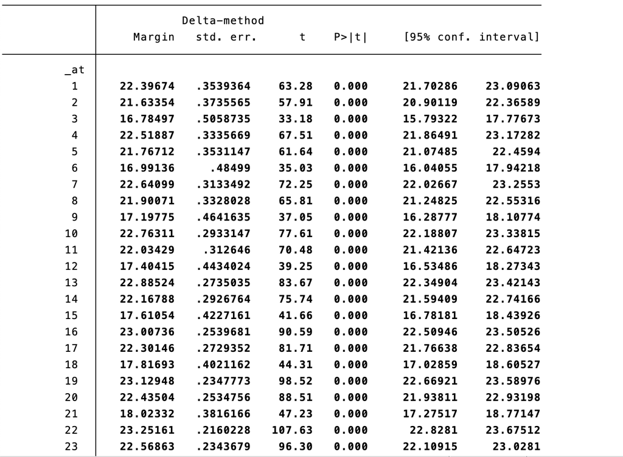

（it’s too long to show so I just post a snippet here👆)

Marginsplot:

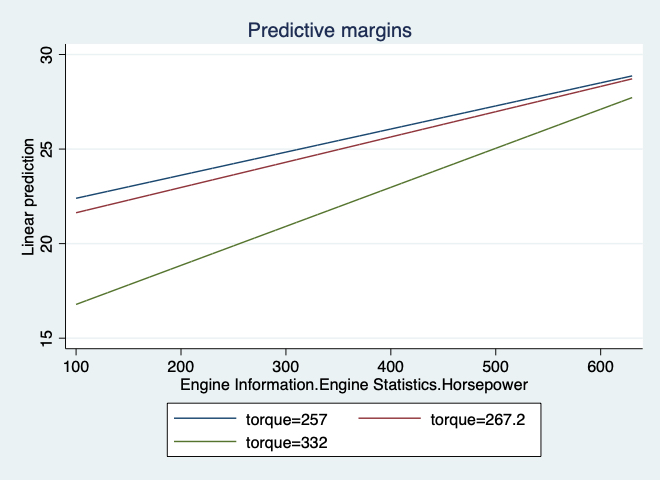